# NCAA Tournament Historical Outcomes

Matt O’Neil

2/22/2022

# The Idea

You’ve probably heard the statistic that every national champion in the Kenpom era has had a top-20 AdjO and AdjD, other than 2014 UConn. That can be informative when you’re filling out the rest of your bracket, but I wanted a better sense of broader trends.

For example:

- What does the typical Final 4 team look like?
  - What percentage of Final 4 teams fit the mold of the Kenpom champion?
  - For those that don’t, what trends stick out?
- You probably know to pick a couple 12 and 13 seeds to win a game and maybe even get to the Sweet 16, but how do you determine which ones?
  - Are there certain metrics, such as an elite offense or an elite defense, that makes them more likely to go far?
  - Does it require a star, like Oral Roberts’ Max Abmas?
  - Are upsets more matchup dependent, such as Texas, a team that turned it over frequently, against Abilene Christian, a team that forces turnovers in droves?
- What is a sign of a high sided team likely to be upset early?
  - Like Texas, does it show up in the matchup?
  - Is it a team that isn’t as respected by Kenpom’s metrics as it is by polls and record?
  - Is it a team with an elite offense and a bad defense that has a really bad shooting day?

# Champions

- Only two teams fell out of the top-20 in either AdjO or AdjD
  - An historical outlier in UConn (2014) and last year Baylor, but they just missed with the 22nd ranked Defense on a team ravaged by Covid for a period
- Every other champion falls in the top 20 of both

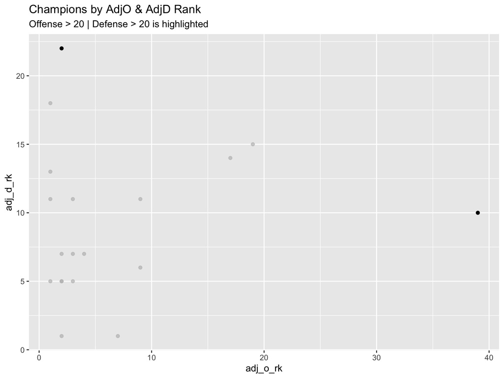

| team | year | seed | Tempo | O | D | O_EFG | O_TO | O_OR | O_FTR | D_EFG | D_TO | D_OR | D_FTR |
| --- | --- | --- | --- | --- | --- | --- | --- | --- | --- | --- | --- | --- | --- |
| Baylor | 2021 | 1 | 213 | 2 | 22 | 7 | 54 | 5 | 295 | 121 | 4 | 274 | 167 |
| Connecticut | 2014 | 7 | 254 | 39 | 10 | 84 | 103 | 210 | 233 | 15 | 82 | 248 | 79 |

# Championship Takeaways

- That leaves us with the following teams that have a chance of winning a title right now
- It’s early right now so there’s time for others to join
- It remains to be seen how much progress could be made, but this is not a final list right now

Possible Champions for 2022

Offense & Defense <= 20

| team | seed | Tempo | O | D | O_EFG | O_TO | O_OR | O_FTR | D_EFG | D_TO | D_OR | D_FTR |
| --- | --- | --- | --- | --- | --- | --- | --- | --- | --- | --- | --- | --- |
| Arizona | 1 | 8 | 5 | 20 | 10 | 142 | 17 | 57 | 9 | 222 | 190 | 20 |
| Baylor | 1 | 169 | 9 | 14 | 54 | 160 | 7 | 236 | 79 | 16 | 198 | 89 |
| Gonzaga | 1 | 4 | 1 | 7 | 2 | 39 | 149 | 188 | 1 | 267 | 21 | 16 |
| Houston | 5 | 333 | 10 | 11 | 34 | 90 | 3 | 230 | 3 | 30 | 141 | 289 |
| UCLA | 4 | 258 | 15 | 12 | 146 | 5 | 58 | 189 | 75 | 92 | 54 | 152 |

# Historical Championship Criteria

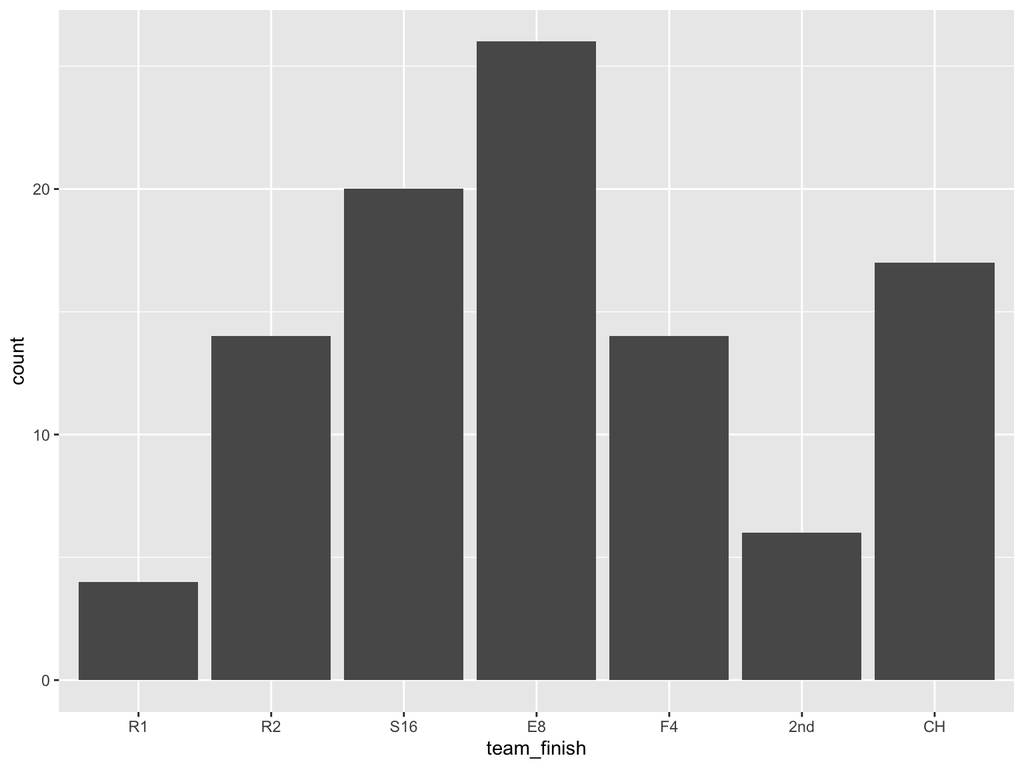

# Final History

- Of teams that made the final, only four had Offensive + Defensive rank > 40
  - Butler (Gordon Hayward) made a deep run on the backs of of their stars
  - Kentucky was an underseeded young team that just took some time to get going
  - That 2014 UConn team (that beat Kentucky) was an historic outlier, both as a champion and a finalist

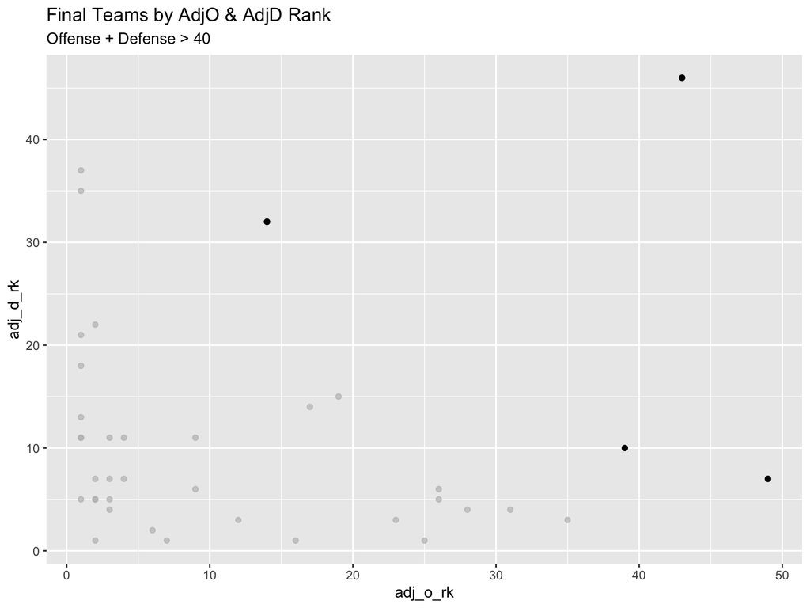

Championship Game History

Offense + Defense > 40

| team | year | seed | Tempo | O | D | O_EFG | O_TO | O_OR | O_FTR | D_EFG | D_TO | D_OR | D_FTR |
| --- | --- | --- | --- | --- | --- | --- | --- | --- | --- | --- | --- | --- | --- |
| Butler | 2011 | 8 | 262 | 43 | 46 | 130 | 22 | 138 | 164 | 118 | 251 | 18 | 197 |
| Butler | 2010 | 5 | 286 | 49 | 7 | 80 | 92 | 241 | 16 | 68 | 73 | 24 | 110 |
| Connecticut | 2014 | 7 | 254 | 39 | 10 | 84 | 103 | 210 | 233 | 15 | 82 | 248 | 79 |
| Kentucky | 2014 | 8 | 217 | 14 | 32 | 151 | 150 | 2 | 12 | 40 | 303 | 100 | 99 |

# Final Takeaways

2022 Possible Teams to make the National Championship

Offense + Defense <= 40

| team | seed | Tempo | O | D | O_EFG | O_TO | O_OR | O_FTR | D_EFG | D_TO | D_OR | D_FTR |
| --- | --- | --- | --- | --- | --- | --- | --- | --- | --- | --- | --- | --- |
| Arizona | 1 | 8 | 5 | 20 | 10 | 142 | 17 | 57 | 9 | 222 | 190 | 20 |
| Auburn | 2 | 40 | 24 | 8 | 155 | 65 | 42 | 133 | 8 | 52 | 230 | 288 |
| Baylor | 1 | 169 | 9 | 14 | 54 | 160 | 7 | 236 | 79 | 16 | 198 | 89 |
| Gonzaga | 1 | 4 | 1 | 7 | 2 | 39 | 149 | 188 | 1 | 267 | 21 | 16 |
| Houston | 5 | 333 | 10 | 11 | 34 | 90 | 3 | 230 | 3 | 30 | 141 | 289 |
| Kansas | 1 | 68 | 6 | 29 | 27 | 128 | 36 | 99 | 45 | 167 | 209 | 104 |
| Kentucky | 2 | 155 | 4 | 27 | 44 | 59 | 4 | 270 | 37 | 233 | 57 | 53 |
| Tennessee | 3 | 172 | 36 | 3 | 159 | 137 | 45 | 203 | 28 | 15 | 152 | 219 |
| UCLA | 4 | 258 | 15 | 12 | 146 | 5 | 58 | 189 | 75 | 92 | 54 | 152 |
| Villanova | 2 | 345 | 8 | 28 | 93 | 30 | 84 | 167 | 64 | 148 | 171 | 52 |

# Historical Final Criteria

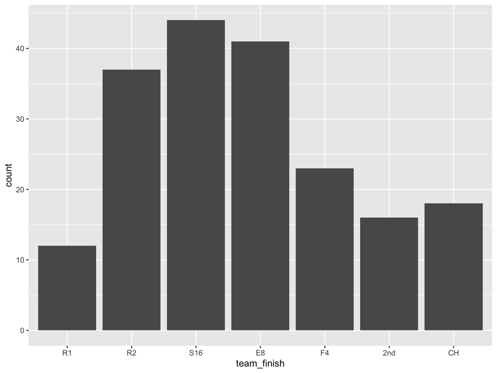

# Final 4 History

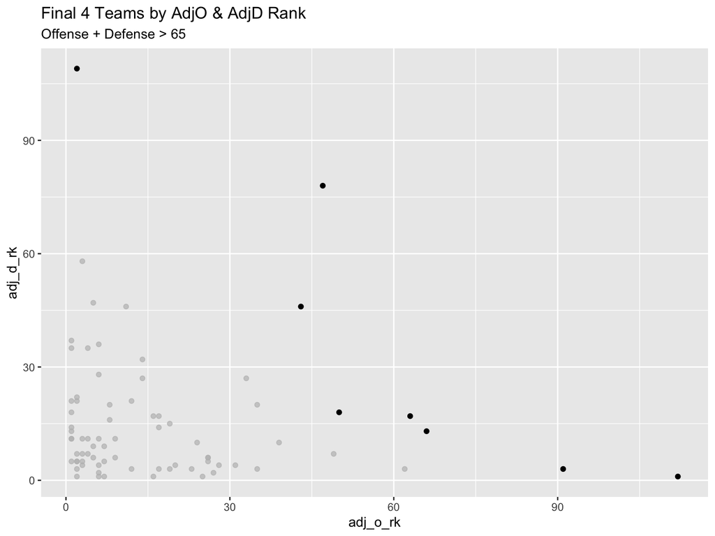

Final 4 History

Offense + Defense > 65

| team | year | seed | Tempo | O | D | O_EFG | O_TO | O_OR | O_FTR | D_EFG | D_TO | D_OR | D_FTR |
| --- | --- | --- | --- | --- | --- | --- | --- | --- | --- | --- | --- | --- | --- |
| Butler | 2011 | 8 | 262 | 43 | 46 | 130 | 22 | 138 | 164 | 118 | 251 | 18 | 197 |
| George Mason | 2006 | 11 | 269 | 66 | 13 | 24 | 72 | 233 | 203 | 10 | 219 | 79 | 17 |
| Louisville | 2012 | 4 | 115 | 112 | 1 | 246 | 215 | 45 | 177 | 4 | 34 | 239 | 129 |
| Loyola Chicago | 2018 | 11 | 307 | 63 | 17 | 7 | 227 | 332 | 210 | 31 | 108 | 58 | 15 |
| LSU | 2006 | 4 | 90 | 62 | 3 | 131 | 195 | 18 | 124 | 32 | 178 | 35 | 4 |
| Marquette | 2003 | 3 | 219 | 2 | 109 | 21 | 62 | 7 | 82 | 75 | 306 | 251 | 75 |
| South Carolina | 2017 | 7 | 145 | 91 | 3 | 304 | 165 | 41 | 52 | 15 | 5 | 275 | 331 |
| Syracuse | 2016 | 10 | 314 | 50 | 18 | 161 | 179 | 52 | 208 | 59 | 48 | 337 | 23 |
| VCU | 2011 | 11 | 156 | 47 | 78 | 74 | 24 | 202 | 195 | 174 | 65 | 316 | 93 |

# Final 4 Takeaways

2022 Teams with a Chance to Make the Final 4

Offense + Defense <= 65

| team | seed | Tempo | O | D | O_EFG | O_TO | O_OR | O_FTR | D_EFG | D_TO | D_OR | D_FTR |
| --- | --- | --- | --- | --- | --- | --- | --- | --- | --- | --- | --- | --- |
| Arizona | 1 | 8 | 5 | 20 | 10 | 142 | 17 | 57 | 9 | 222 | 190 | 20 |
| Arkansas | 4 | 28 | 40 | 16 | 219 | 112 | 85 | 23 | 63 | 56 | 74 | 237 |
| Auburn | 2 | 40 | 24 | 8 | 155 | 65 | 42 | 133 | 8 | 52 | 230 | 288 |
| Baylor | 1 | 169 | 9 | 14 | 54 | 160 | 7 | 236 | 79 | 16 | 198 | 89 |
| Connecticut | 5 | 291 | 21 | 35 | 194 | 110 | 1 | 162 | 25 | 204 | 148 | 229 |
| Duke | 2 | 150 | 7 | 44 | 15 | 17 | 62 | 233 | 47 | 303 | 210 | 2 |
| Gonzaga | 1 | 4 | 1 | 7 | 2 | 39 | 149 | 188 | 1 | 267 | 21 | 16 |
| Houston | 5 | 333 | 10 | 11 | 34 | 90 | 3 | 230 | 3 | 30 | 141 | 289 |
| Illinois | 4 | 177 | 23 | 30 | 47 | 123 | 35 | 130 | 31 | 325 | 76 | 127 |
| Kansas | 1 | 68 | 6 | 29 | 27 | 128 | 36 | 99 | 45 | 167 | 209 | 104 |
| Kentucky | 2 | 155 | 4 | 27 | 44 | 59 | 4 | 270 | 37 | 233 | 57 | 53 |
| Loyola Chicago | 10 | 308 | 42 | 22 | 7 | 175 | 278 | 125 | 48 | 88 | 37 | 125 |
| San Francisco | 10 | 89 | 45 | 19 | 48 | 155 | 106 | 237 | 41 | 160 | 33 | 235 |
| Tennessee | 3 | 172 | 36 | 3 | 159 | 137 | 45 | 203 | 28 | 15 | 152 | 219 |
| Texas | 6 | 341 | 32 | 13 | 174 | 158 | 59 | 113 | 38 | 14 | 252 | 316 |
| UCLA | 4 | 258 | 15 | 12 | 146 | 5 | 58 | 189 | 75 | 92 | 54 | 152 |
| Villanova | 2 | 345 | 8 | 28 | 93 | 30 | 84 | 167 | 64 | 148 | 171 | 52 |

# Historical Final 4 Criteria

# Elite 8 History

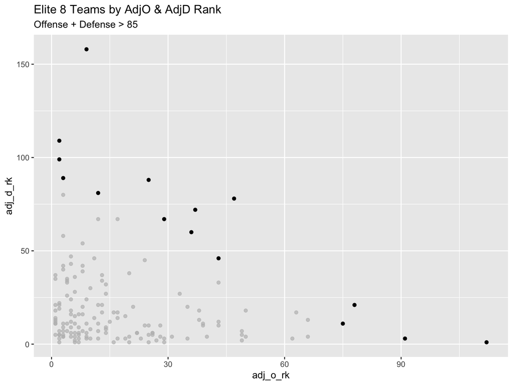

Elite 8 History

Offense + Defense > 85

| team | year | seed | Tempo | O | D | O_EFG | O_TO | O_OR | O_FTR | D_EFG | D_TO | D_OR | D_FTR |
| --- | --- | --- | --- | --- | --- | --- | --- | --- | --- | --- | --- | --- | --- |
| Butler | 2011 | 8 | 262 | 43 | 46 | 130 | 22 | 138 | 164 | 118 | 251 | 18 | 197 |
| Dayton | 2014 | 11 | 223 | 37 | 72 | 52 | 158 | 87 | 162 | 128 | 137 | 56 | 232 |
| Kansas St. | 2018 | 9 | 302 | 78 | 21 | 102 | 85 | 262 | 161 | 80 | 23 | 301 | 250 |
| Louisville | 2012 | 4 | 115 | 112 | 1 | 246 | 215 | 45 | 177 | 4 | 34 | 239 | 129 |
| Marquette | 2003 | 3 | 219 | 2 | 109 | 21 | 62 | 7 | 82 | 75 | 306 | 251 | 75 |
| Michigan | 2014 | 2 | 330 | 3 | 89 | 8 | 17 | 242 | 302 | 157 | 244 | 125 | 2 |
| Missouri | 2002 | 12 | 89 | 12 | 81 | 30 | 71 | 19 | 295 | 172 | 239 | 130 | 125 |
| Notre Dame | 2016 | 6 | 324 | 9 | 158 | 29 | 19 | 70 | 273 | 153 | 335 | 285 | 11 |
| Notre Dame | 2015 | 3 | 226 | 2 | 99 | 1 | 3 | 277 | 174 | 115 | 273 | 228 | 5 |
| Oregon St. | 2021 | 12 | 306 | 36 | 60 | 215 | 103 | 107 | 79 | 106 | 233 | 250 | 311 |
| South Carolina | 2017 | 7 | 145 | 91 | 3 | 304 | 165 | 41 | 52 | 15 | 5 | 275 | 331 |
| Tennessee | 2010 | 6 | 91 | 75 | 11 | 89 | 106 | 155 | 223 | 35 | 33 | 173 | 232 |
| VCU | 2011 | 11 | 156 | 47 | 78 | 74 | 24 | 202 | 195 | 174 | 65 | 316 | 93 |
| West Virginia | 2005 | 7 | 265 | 25 | 88 | 31 | 15 | 273 | 285 | 234 | 67 | 243 | 77 |
| Xavier | 2017 | 11 | 223 | 29 | 67 | 107 | 167 | 31 | 36 | 214 | 244 | 37 | 131 |

# Elite 8 Takeaways

2022 Teams with a Chance to Make the Elite 8

Offense + Defense <= 85

| team | seed | Tempo | O | D | O_EFG | O_TO | O_OR | O_FTR | D_EFG | D_TO | D_OR | D_FTR |
| --- | --- | --- | --- | --- | --- | --- | --- | --- | --- | --- | --- | --- |
| Arizona | 1 | 8 | 5 | 20 | 10 | 142 | 17 | 57 | 9 | 222 | 190 | 20 |
| Arkansas | 4 | 28 | 40 | 16 | 219 | 112 | 85 | 23 | 63 | 56 | 74 | 237 |
| Auburn | 2 | 40 | 24 | 8 | 155 | 65 | 42 | 133 | 8 | 52 | 230 | 288 |
| Baylor | 1 | 169 | 9 | 14 | 54 | 160 | 7 | 236 | 79 | 16 | 198 | 89 |
| Connecticut | 5 | 291 | 21 | 35 | 194 | 110 | 1 | 162 | 25 | 204 | 148 | 229 |
| Duke | 2 | 150 | 7 | 44 | 15 | 17 | 62 | 233 | 47 | 303 | 210 | 2 |
| Gonzaga | 1 | 4 | 1 | 7 | 2 | 39 | 149 | 188 | 1 | 267 | 21 | 16 |
| Houston | 5 | 333 | 10 | 11 | 34 | 90 | 3 | 230 | 3 | 30 | 141 | 289 |
| Illinois | 4 | 177 | 23 | 30 | 47 | 123 | 35 | 130 | 31 | 325 | 76 | 127 |
| Iowa | 5 | 52 | 2 | 77 | 33 | 3 | 55 | 174 | 171 | 120 | 262 | 72 |
| Kansas | 1 | 68 | 6 | 29 | 27 | 128 | 36 | 99 | 45 | 167 | 209 | 104 |
| Kentucky | 2 | 155 | 4 | 27 | 44 | 59 | 4 | 270 | 37 | 233 | 57 | 53 |
| Loyola Chicago | 10 | 308 | 42 | 22 | 7 | 175 | 278 | 125 | 48 | 88 | 37 | 125 |
| Memphis | 9 | 34 | 50 | 31 | 65 | 352 | 5 | 16 | 35 | 45 | 288 | 250 |
| Murray St. | 7 | 246 | 35 | 40 | 52 | 91 | 11 | 150 | 85 | 41 | 67 | 45 |
| Saint Mary's | 5 | 338 | 63 | 9 | 64 | 86 | 203 | 341 | 103 | 107 | 4 | 42 |
| San Francisco | 10 | 89 | 45 | 19 | 48 | 155 | 106 | 237 | 41 | 160 | 33 | 235 |
| Tennessee | 3 | 172 | 36 | 3 | 159 | 137 | 45 | 203 | 28 | 15 | 152 | 219 |
| Texas | 6 | 341 | 32 | 13 | 174 | 158 | 59 | 113 | 38 | 14 | 252 | 316 |
| Texas Tech | 3 | 211 | 65 | 1 | 74 | 295 | 41 | 46 | 22 | 10 | 89 | 232 |
| UCLA | 4 | 258 | 15 | 12 | 146 | 5 | 58 | 189 | 75 | 92 | 54 | 152 |
| Villanova | 2 | 345 | 8 | 28 | 93 | 30 | 84 | 167 | 64 | 148 | 171 | 52 |
| Virginia Tech | 11 | 344 | 18 | 55 | 20 | 75 | 172 | 334 | 117 | 146 | 90 | 55 |

# Historical Elite 8 Criteria

# Sweet 16 History

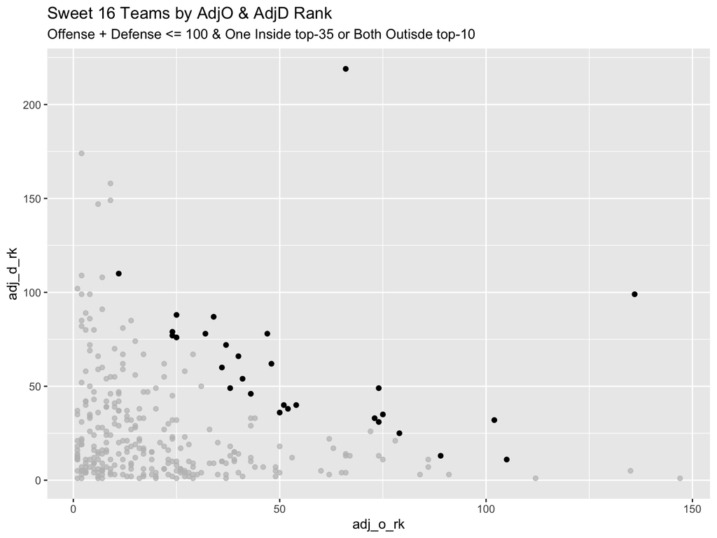

Sweet 16 History

Offense + Defense <= 100 & One Inside top-35 or both Outisde top-10

| team | year | seed | Tempo | O | D | O_EFG | O_TO | O_OR | O_FTR | D_EFG | D_TO | D_OR | D_FTR |
| --- | --- | --- | --- | --- | --- | --- | --- | --- | --- | --- | --- | --- | --- |
| Auburn | 2003 | 10 | 181 | 74 | 31 | 69 | 255 | 52 | 189 | 92 | 93 | 238 | 31 |
| Butler | 2011 | 8 | 262 | 43 | 46 | 130 | 22 | 138 | 164 | 118 | 251 | 18 | 197 |
| Butler | 2003 | 12 | 325 | 11 | 110 | 6 | 9 | 301 | 261 | 182 | 251 | 205 | 13 |
| Dayton | 2014 | 11 | 223 | 37 | 72 | 52 | 158 | 87 | 162 | 128 | 137 | 56 | 232 |
| Florida Gulf Coast | 2013 | 15 | 41 | 136 | 99 | 59 | 242 | 138 | 203 | 106 | 55 | 215 | 90 |
| La Salle | 2013 | 13 | 177 | 34 | 87 | 50 | 28 | 262 | 286 | 201 | 91 | 269 | 27 |
| Milwaukee | 2005 | 12 | 59 | 52 | 38 | 86 | 69 | 55 | 150 | 45 | 31 | 214 | 181 |
| N.C. State | 2015 | 8 | 188 | 25 | 76 | 156 | 25 | 80 | 222 | 37 | 346 | 124 | 133 |
| N.C. State | 2012 | 11 | 83 | 32 | 78 | 118 | 83 | 44 | 174 | 85 | 254 | 125 | 71 |
| Ohio | 2012 | 13 | 121 | 102 | 32 | 175 | 130 | 97 | 175 | 88 | 2 | 267 | 293 |
| Oral Roberts | 2021 | 15 | 46 | 66 | 219 | 56 | 16 | 309 | 270 | 175 | 194 | 334 | 174 |
| Oregon | 2013 | 12 | 37 | 105 | 11 | 128 | 256 | 47 | 104 | 79 | 64 | 27 | 111 |
| Oregon St. | 2021 | 12 | 306 | 36 | 60 | 215 | 103 | 107 | 79 | 106 | 233 | 250 | 311 |
| Richmond | 2011 | 12 | 309 | 41 | 54 | 24 | 11 | 279 | 297 | 20 | 207 | 246 | 29 |
| Southern Illinois | 2002 | 11 | 71 | 73 | 33 | 79 | 47 | 86 | 67 | 24 | 152 | 96 | 256 |
| Stanford | 2014 | 10 | 147 | 54 | 40 | 97 | 73 | 244 | 58 | 109 | 249 | 35 | 104 |
| Syracuse | 2021 | 11 | 151 | 24 | 77 | 104 | 49 | 122 | 255 | 78 | 88 | 339 | 23 |
| Texas Tech | 2005 | 6 | 55 | 50 | 36 | 76 | 27 | 225 | 192 | 168 | 37 | 220 | 19 |
| UAB | 2004 | 9 | 20 | 79 | 25 | 143 | 18 | 236 | 263 | 109 | 8 | 287 | 284 |
| UCLA | 2015 | 11 | 101 | 40 | 66 | 139 | 80 | 87 | 207 | 150 | 244 | 69 | 76 |
| UNLV | 2007 | 7 | 190 | 51 | 40 | 133 | 3 | 129 | 241 | 101 | 102 | 228 | 124 |
| Vanderbilt | 2007 | 6 | 126 | 24 | 79 | 50 | 24 | 287 | 265 | 196 | 131 | 161 | 71 |
| VCU | 2011 | 11 | 156 | 47 | 78 | 74 | 24 | 202 | 195 | 174 | 65 | 316 | 93 |
| Villanova | 2008 | 12 | 74 | 75 | 35 | 196 | 135 | 64 | 107 | 223 | 50 | 96 | 322 |
| West Virginia | 2005 | 7 | 265 | 25 | 88 | 31 | 15 | 273 | 285 | 234 | 67 | 243 | 77 |
| Western Kentucky | 2008 | 12 | 69 | 48 | 62 | 39 | 112 | 39 | 193 | 54 | 18 | 214 | 329 |
| Wichita St. | 2006 | 7 | 267 | 38 | 49 | 126 | 76 | 107 | 143 | 53 | 306 | 11 | 22 |
| Wisconsin | 2016 | 7 | 344 | 89 | 13 | 234 | 106 | 60 | 135 | 83 | 142 | 79 | 105 |
| Xavier | 2012 | 10 | 104 | 74 | 49 | 142 | 62 | 184 | 52 | 37 | 260 | 97 | 158 |

# Sweet 16 Takeaways

Teams with a Chance to Make the Sweet 16

Offense + Defense <= 100 & One Inside top-35 or One Inside top-10

| team | seed | Tempo | O | D | O_EFG | O_TO | O_OR | O_FTR | D_EFG | D_TO | D_OR | D_FTR |
| --- | --- | --- | --- | --- | --- | --- | --- | --- | --- | --- | --- | --- |
| Arizona | 1 | 8 | 5 | 20 | 10 | 142 | 17 | 57 | 9 | 222 | 190 | 20 |
| Arkansas | 4 | 28 | 40 | 16 | 219 | 112 | 85 | 23 | 63 | 56 | 74 | 237 |
| Auburn | 2 | 40 | 24 | 8 | 155 | 65 | 42 | 133 | 8 | 52 | 230 | 288 |
| Baylor | 1 | 169 | 9 | 14 | 54 | 160 | 7 | 236 | 79 | 16 | 198 | 89 |
| Boise St. | 8 | 307 | 76 | 17 | 123 | 189 | 95 | 54 | 96 | 82 | 5 | 63 |
| Connecticut | 5 | 291 | 21 | 35 | 194 | 110 | 1 | 162 | 25 | 204 | 148 | 229 |
| Duke | 2 | 150 | 7 | 44 | 15 | 17 | 62 | 233 | 47 | 303 | 210 | 2 |
| Gonzaga | 1 | 4 | 1 | 7 | 2 | 39 | 149 | 188 | 1 | 267 | 21 | 16 |
| Houston | 5 | 333 | 10 | 11 | 34 | 90 | 3 | 230 | 3 | 30 | 141 | 289 |
| Illinois | 4 | 177 | 23 | 30 | 47 | 123 | 35 | 130 | 31 | 325 | 76 | 127 |
| Iowa | 5 | 52 | 2 | 77 | 33 | 3 | 55 | 174 | 171 | 120 | 262 | 72 |
| Iowa St. | 11 | 232 | 151 | 10 | 181 | 300 | 168 | 250 | 107 | 6 | 203 | 308 |
| Kansas | 1 | 68 | 6 | 29 | 27 | 128 | 36 | 99 | 45 | 167 | 209 | 104 |
| Kentucky | 2 | 155 | 4 | 27 | 44 | 59 | 4 | 270 | 37 | 233 | 57 | 53 |
| Loyola Chicago | 10 | 308 | 42 | 22 | 7 | 175 | 278 | 125 | 48 | 88 | 37 | 125 |
| LSU | 6 | 92 | 89 | 5 | 201 | 304 | 27 | 96 | 15 | 2 | 296 | 332 |
| Memphis | 9 | 34 | 50 | 31 | 65 | 352 | 5 | 16 | 35 | 45 | 288 | 250 |
| Murray St. | 7 | 246 | 35 | 40 | 52 | 91 | 11 | 150 | 85 | 41 | 67 | 45 |
| North Carolina | 8 | 38 | 27 | 64 | 83 | 55 | 103 | 200 | 172 | 347 | 2 | 10 |
| Purdue | 3 | 248 | 3 | 100 | 4 | 101 | 13 | 40 | 162 | 346 | 30 | 9 |
| Saint Mary's | 5 | 338 | 63 | 9 | 64 | 86 | 203 | 341 | 103 | 107 | 4 | 42 |
| San Diego St. | 8 | 268 | 157 | 2 | 238 | 236 | 127 | 141 | 5 | 29 | 123 | 189 |
| San Francisco | 10 | 89 | 45 | 19 | 48 | 155 | 106 | 237 | 41 | 160 | 33 | 235 |
| Tennessee | 3 | 172 | 36 | 3 | 159 | 137 | 45 | 203 | 28 | 15 | 152 | 219 |
| Texas | 6 | 341 | 32 | 13 | 174 | 158 | 59 | 113 | 38 | 14 | 252 | 316 |
| Texas Tech | 3 | 211 | 65 | 1 | 74 | 295 | 41 | 46 | 22 | 10 | 89 | 232 |
| UCLA | 4 | 258 | 15 | 12 | 146 | 5 | 58 | 189 | 75 | 92 | 54 | 152 |
| Villanova | 2 | 345 | 8 | 28 | 93 | 30 | 84 | 167 | 64 | 148 | 171 | 52 |
| Virginia Tech | 11 | 344 | 18 | 55 | 20 | 75 | 172 | 334 | 117 | 146 | 90 | 55 |

# Historical Sweet 16 Criteria

# Summary

| Round | all_teams | outliers | possibles | error_rate | Coverage |
| --- | --- | --- | --- | --- | --- |
| S16 | 304 | 29 | 29 | 9.54% | 1.81 |
| E8 | 152 | 15 | 23 | 9.87% | 2.88 |
| F4 | 76 | 9 | 17 | 11.84% | 4.25 |
| Final | 38 | 4 | 10 | 10.53% | 5.00 |
| CH | 19 | 2 | 5 | 10.53% | 5.00 |

# 12+ Upsets

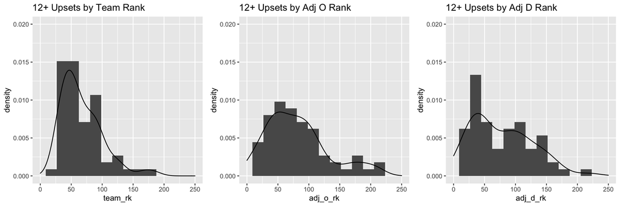

# 12+ Upsets, Continued

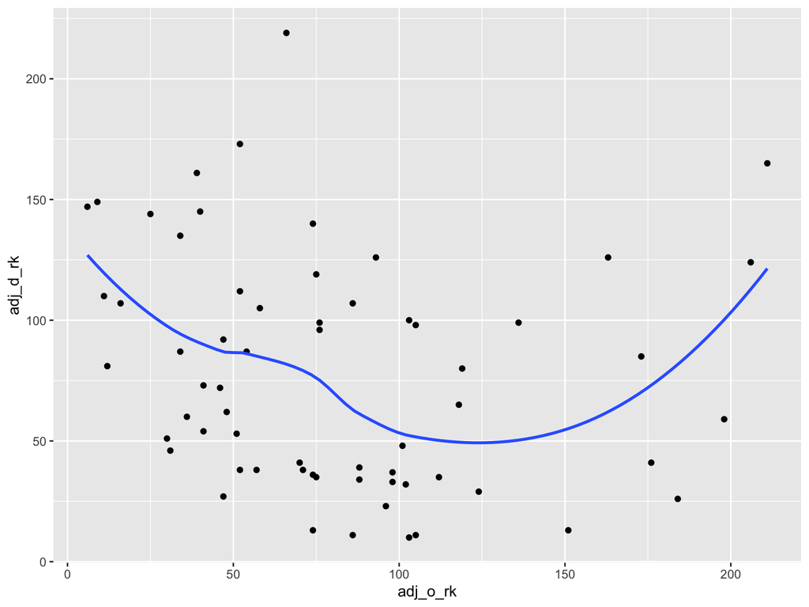

# 10+ S16

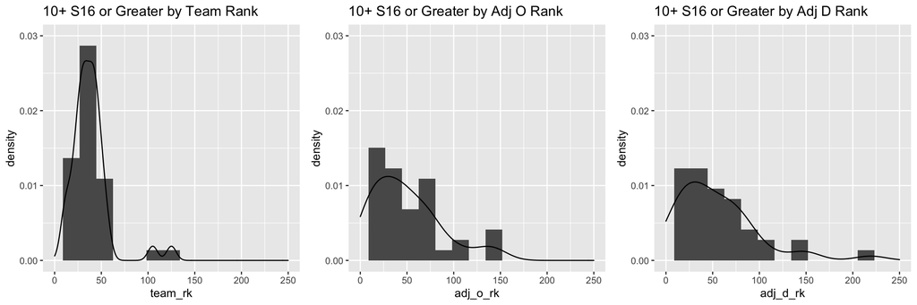

# 10+ S16, Continued

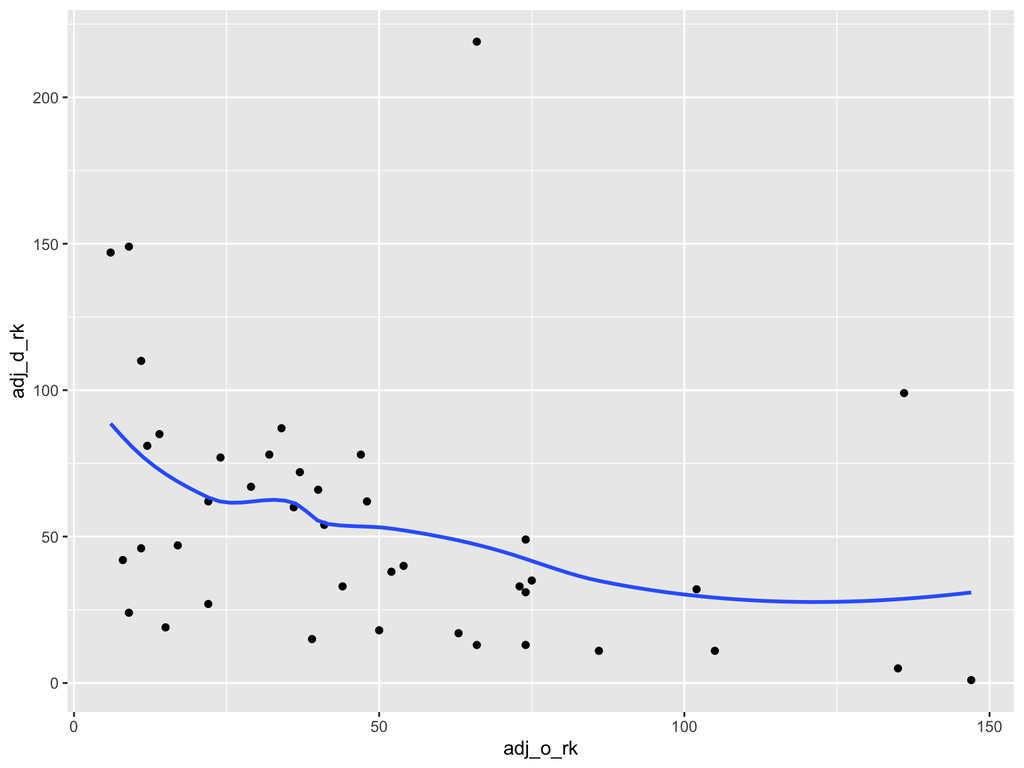

# Citations

```
## @Manual{,
##   title = {rmarkdown: Dynamic Documents for R},
##   author = {JJ Allaire and Yihui Xie and Jonathan McPherson and Javier Luraschi and Kevin Ushey and Aron Atkins and Hadley Wickham and Joe Cheng and Winston Chang and Richard Iannone},
##   year = {2021},
##   note = {R package version 2.11},
##   url = {https://github.com/rstudio/rmarkdown},
## }
##
## @Book{,
##   title = {R Markdown: The Definitive Guide},
##   author = {Yihui Xie and J.J. Allaire and Garrett Grolemund},
##   publisher = {Chapman and Hall/CRC},
##   address = {Boca Raton, Florida},
##   year = {2018},
##   note = {ISBN 9781138359338},
##   url = {https://bookdown.org/yihui/rmarkdown},
## }
##
## @Book{,
##   title = {R Markdown Cookbook},
##   author = {Yihui Xie and Christophe Dervieux and Emily Riederer},
##   publisher = {Chapman and Hall/CRC},
##   address = {Boca Raton, Florida},
##   year = {2020},
##   note = {ISBN 9780367563837},
##   url = {https://bookdown.org/yihui/rmarkdown-cookbook},
## }
```

```
## @Article{,
##   title = {Welcome to the {tidyverse}},
##   author = {Hadley Wickham and Mara Averick and Jennifer Bryan and Winston Chang and Lucy D'Agostino McGowan and Romain François and Garrett Grolemund and Alex Hayes and Lionel Henry and Jim Hester and Max Kuhn and Thomas Lin Pedersen and Evan Miller and Stephan Milton Bache and Kirill Müller and…
##   year = {2019},
##   journal = {Journal of Open Source Software},
##   volume = {4},
##   number = {43},
##   pages = {1686},
##   doi = {10.21105/joss.01686},
## }
```

```
## @Manual{,
##   title = {hoopR: Functions to Access Men's Basketball Play by Play Data},
##   author = {Saiem Gilani},
##   year = {2021},
##   note = {R package version 1.5.0},
##   url = {https://CRAN.R-project.org/package=hoopR},
## }
```

```
## @Manual{,
##   title = {rvest: Easily Harvest (Scrape) Web Pages},
##   author = {Hadley Wickham},
##   year = {2021},
##   note = {R package version 1.0.2},
##   url = {https://CRAN.R-project.org/package=rvest},
## }
```

```
## @Article{,
##   title = {stringi: Fast and portable character string processing in R},
##   author = {Marek Gagolewski},
##   journal = {Journal of Statistical Software},
##   year = {2021},
##   note = {to appear},
## }
##
## @Manual{,
##   title = {stringi: Fast and portable character string processing in R},
##   author = {Marek Gagolewski},
##   year = {2021},
##   note = {R package version 1.7.6},
##   url = {https://stringi.gagolewski.com/},
## }
```

```
## @Manual{,
##   title = {furrr: Apply Mapping Functions in Parallel using Futures},
##   author = {Davis Vaughan and Matt Dancho},
##   year = {2021},
##   note = {R package version 0.2.3},
##   url = {https://CRAN.R-project.org/package=furrr},
## }
```

```
## @Book{,
##   author = {Hadley Wickham},
##   title = {ggplot2: Elegant Graphics for Data Analysis},
##   publisher = {Springer-Verlag New York},
##   year = {2016},
##   isbn = {978-3-319-24277-4},
##   url = {https://ggplot2.tidyverse.org},
## }
```

```
## @Manual{,
##   title = {glue: Interpreted String Literals},
##   author = {Jim Hester and Jennifer Bryan},
##   year = {2021},
##   note = {R package version 1.6.0},
##   url = {https://CRAN.R-project.org/package=glue},
## }
```

```
## @Manual{,
##   title = {collapse: Advanced and Fast Data Transformation},
##   author = {Sebastian Krantz},
##   year = {2022},
##   note = {R package version 1.7.5},
##   url = {https://CRAN.R-project.org/package=collapse},
## }
```

```
## @Manual{,
##   title = {ggrepel: Automatically Position Non-Overlapping Text Labels with
## 'ggplot2'},
##   author = {Kamil Slowikowski},
##   year = {2021},
##   note = {R package version 0.9.1},
##   url = {https://CRAN.R-project.org/package=ggrepel},
## }
```

```
## @Manual{,
##   title = {dplyr: A Grammar of Data Manipulation},
##   author = {Hadley Wickham and Romain François and Lionel Henry and Kirill Müller},
##   year = {2021},
##   note = {R package version 1.0.7},
##   url = {https://CRAN.R-project.org/package=dplyr},
## }
```

```
## @Manual{,
##   title = {gtExtras: A Collection of Helper Functions for the gt Package},
##   author = {Thomas Mock},
##   year = {2022},
##   note = {R package version 0.2.3},
##   url = {https://github.com/jthomasmock/gtExtras},
## }
```

```
## @Manual{,
##   title = {gt: Easily Create Presentation-Ready Display Tables},
##   author = {Richard Iannone and Joe Cheng and Barret Schloerke},
##   year = {2021},
##   note = {R package version 0.3.1},
##   url = {https://CRAN.R-project.org/package=gt},
## }
```

```
## @Manual{,
##   title = {gghighlight: Highlight Lines and Points in 'ggplot2'},
##   author = {Hiroaki Yutani},
##   year = {2021},
##   note = {R package version 0.3.2},
##   url = {https://CRAN.R-project.org/package=gghighlight},
## }
```

```
## @Manual{,
##   title = {readr: Read Rectangular Text Data},
##   author = {Hadley Wickham and Jim Hester and Jennifer Bryan},
##   year = {2021},
##   note = {R package version 2.1.1},
##   url = {https://CRAN.R-project.org/package=readr},
## }
```

```
## @Manual{,
##   title = {gridExtra: Miscellaneous Functions for "Grid" Graphics},
##   author = {Baptiste Auguie},
##   year = {2017},
##   note = {R package version 2.3},
##   url = {https://CRAN.R-project.org/package=gridExtra},
## }
```